# mxd - an R package for MaxDiff in R

May 2025

# Introduction

`mxd` uses the `tidyverse` programming logic (Wickham et al. 2019); for more information please see [here](https://dplyr.tidyverse.org/articles/programming.html).

# Motivation

# Statement of need

# Workflow

## Preparation

In the first step, we load the `mxd` package. In addition, we take a glimpse at the data structure of the design. We included an exemplary data frame to show how the design is usually exported. We have a total of five columns:

- `ID`: participant’s unique identifier
- `Set`: choice set variable
- `Position`: variable displaying the alternatives
- `Item`: item that was shown
- `Response`: participant’s choice, `1` indicates best choice and `-1` indicates worst choice

```r
library(mxd)
design <- readRDS("../data/design.rds")
head(design)
```

```
##   ID Set Position Item Response
## 1  1   1        1   10       -1
## 2  1   1        2    3        0
## 3  1   1        3    9        0
## 4  1   1        4    4        1
## 5  1   2        1   11        0
## 6  1   2        2    6        1
```

To convert this into the right format, we use the `csv_to_dm()` function, which works both with anchored and unanchored MxDiff studies. For the `anchor` argument (default set to `NULL`), the user can choose from both `direct` or `indirect`. `csv_to_dm()` also supports different coding mechanisms, namely:

- `best-worst`: best and worst choice set are identical and made independent of each other
- `best-worst-seq`: first best is chosen, afterwards worst from a reduced choice set (i.e., best choice set is excluded from the choice set of the worst alternative)
- `worst-best-seq`: see definition of `best-worst-seq`; however, order is switched
- `best-only`: only the best choices are considered
- `worst-only`: only the worst choices are considered
- `maxdiff`: pair of items with the maximum difference is chosen
- `exploded`: exploded pairs

Next, the user has to define the arguments `id` (participants’ identifier), `cs` (variable indicating the choice set) `item` (variable that defines which item was shown) and `ch` (the variable that defines whether a variable was chosen as best or as worst. In addition, the user also has to define the number of MaxDiff tasks per participant (`mxd_tasks`).

```r
dm <- csv_to_dm(
  design = design,
  id = ID,
  cs = Set,
  item = Item,
  ch = Response,
  anchor = "direct",
  mxd_tasks = 16L,
  type = "best-worst"
)

head(dm)
```

```
##   ID Set alt Item_1 Item_2 Item_3 Item_4 Item_5 Item_6 Item_7 Item_8 Item_9
## 1  1   1   1      0      0      1      0      0      0      0      0      0
## 2  1   1   2      0      0      0      1      0      0      0      0      0
## 3  1   1   3      0      0      0      0      0      0      0      0      0
## 4  1   1   4      0      0      0      0      0      0      0      0      1
## 5  1   2   1      0      0     -1      0      0      0      0      0      0
## 6  1   2   2      0      0      0     -1      0      0      0      0      0
##   Item_10 Item_11 Item_12 Item_13 Item_14 Item_15 Item_16 Item_17 choice
## 1       0       0       0       0       0       0       0       0      0
## 2       0       0       0       0       0       0       0       0      1
## 3       1       0       0       0       0       0       0       0      0
## 4       0       0       0       0       0       0       0       0      0
## 5       0       0       0       0       0       0       0       0      0
## 6       0       0       0       0       0       0       0       0      0
```

Often, users, who rely on *R* to create the MaxDiff design, use the `crossdes` (Sailer 2022) or `support.BWS` (Aizaki and Fogarty 2023) packages. For these users, we implemented the `bibd_to_dm()` function, which allows users to convert their data set and design into the format required by `mxd`. Below, we illustrate the workflow accordingly. In the intial step, we create both design and data set by relying on the code that is provided in `support.BWS` (Aizaki and Fogarty 2023).

```r
library(support.BWS)
library(crossdes)
set.seed(1)
bibd_design <- find.BIB(trt = 7, b = 7, k = 4)
items <- c("apple", "orange", "grapes", "banana", "peach", "melon", "pear")
b <- c(1, 0.6, 0.3, -0.3, -0.5, -1, 0)
dataset <- bws.response(design = bibd_design, item.names = items, b = b, n = 100, seed = 1)
```

Next, we can apply the `bibd_to_dm()` function. The user has to provide both the `design` and data set (`data`; i.e., which includes the participants’ best and worst choices). In addition, the participants’ identifier (`id`), the columns that include the best choices (`best_ch`) and worst choices (`worst_ch`), and the type of coding (`type`; see above) are required.

```r
bibd_dm <- bibd_to_dm(
  design = bibd_design,
  data = dataset,
  id = id,
  best_ch = c(B1, B2, B3, B4, B5, B6, B7),
  worst_ch = c(W1, W2, W3, W4, W5, W6, W7),
  type = "best-worst"
)
```

## Estimation

### Classical frequentist MNL

To run the multinomial logit model, `mxd` provides the `mxd_logit()`. The function relies on the `logitr` (Helveston 2023) package for estimation. From a user perspective, the `data`, the column that includes the actual choice (`ch`), and the choice set column (`cs`). For the `items` (i.e., predictors) the user has to provide **all** variables. In addition, the user can decide which item should be used as reference. If `reference` is left empty, the last predictor is automatically chosen as reference level. Finally, the user has to indicate whether it is an anchored or an unanchored MaxDiif (i.e., set `anchor` to `TRUE` or `FALSE`, respectively). Finally, the argument`bw_size` defines the size of the MaxDiff tasks. The output provides both raw utilities as well as centered one and important scores.

```r
mxd_logit(
  data = dm,
  ch = choice,
  cs = Set,
  items = c(Item_1:Item_17),
  bw_size = 4,
  reference = Item_17,
  anchor = TRUE
)
```

```
## Running model...
```

```
## Done!
```

```
##      items          est       std          zc    zc_se      prob
## 1   Item_1 -0.355987730 0.1261351 -22.9933786 8.147114  75.71785
## 2   Item_2 -0.239608316 0.1259701 -15.4763894 8.136455  83.12113
## 3   Item_3 -0.324654624 0.1260988 -20.9695618 8.144766  77.65998
## 4   Item_4 -0.443193319 0.1265453 -28.6260197 8.173607  70.50918
## 5   Item_5  0.282301959 0.1265568  18.2339875 8.174347 122.61897
## 6   Item_6  0.337292493 0.1268313  21.7858464 8.192079 127.34392
## 7   Item_7 -0.630477989 0.1271222 -40.7228056 8.210873  60.28159
## 8   Item_8 -0.740317578 0.1276705 -47.8173850 8.246286  54.87116
## 9   Item_9 -0.927206876 0.1288885 -59.8886337 8.324954  46.60745
## 10 Item_10  0.150748820 0.1260755   9.7369218 8.143264 111.72588
## 11 Item_11  0.180021115 0.1262835  11.6276301 8.156696 114.09802
## 12 Item_12  0.009962869 0.1257876   0.6435053 8.124669 100.74907
## 13 Item_13 -0.027832061 0.1258987  -1.7976830 8.131842  97.92715
## 14 Item_14 -0.980572914 0.1292895 -63.3355657 8.350855  44.45457
## 15 Item_15  0.198025848 0.1263165  12.7905625 8.158826 115.57200
## 16 Item_16 -1.210925957 0.1314151 -78.2141536 8.488147  36.13443
## 17 Item_17  0.000000000        NA   0.0000000       NA 100.00000
```

### Bayesian MNL

Alternatively, the user can also run the MNL model in a Bayesian manner. `mxd` uses the `rstan` package (2025) to run the Bayesian models. The Stan code for the MNL model is the following:

```r
cat(rstan::get_stancode(mxd:::stanmodels$mnl))
```

```
## data {
##   int<lower=1> N;                     // number of choices (and choice tasks)
##   int<lower=1> M;                     // number of observations (rows in X)
##   int<lower=1> K;                     // number of items
##   int<lower=1> item[M];               // vector of items
##   int<lower=-1> bw[M];                // vector of best-worst indicator (1 = best; -1 = worst)
##   int<lower=1> y[N];                  // row number in X that belongs to nth choice
##   int<lower=1> start_n[N];            // row number in X where nth choice task starts
##   int<lower=1> end_n[N];              // row number in X where nth choice task ends
##   real<lower=0> prior_b;              // prior
## }
## parameters {
##   vector[K] b;                        // parameters
## }
## transformed parameters {
##   real<upper=0> log_lik = 0;
##   vector[K + 1] b0;                   // parameters (incl. 0)
##   b0 = append_row(b, 0);
##   for (n in 1:N) {
##     log_lik += bw[y[n]] * b0[item[y[n]]] - log_sum_exp(bw[y[n]] * b0[item[start_n[n]:end_n[n]]]);
##   }
## }
## model {
##   b ~ normal(0, prior_b);
##   target += log_lik;
## }
```

To run the Bayesian MNL model, we first need to prepare the input for the model. `mxd` provides the `dm_to_stan_mnl()` function to do so. To run the `dm_to_stan_mnl()` function, the user has to provide the design matrix (`dm`), the participants’ identifier (`id`), the choice set variable (`cs`), the choice variable (`ch`), and the items (`items`; again, all items should be provided). The default prior for `b` is set to `5` (i.e., weakly informative prior), however, can be adapted as shown in the example below.

```r
data_stan <- dm_to_stan_mnl(
  design = dm,
  id = ID,
  cs = Set,
  items = c(Item_1:Item_17),
  ch = choice,
  prior_b = 10)
```

Next, we can run the estimation. For demonstration purposes, we lower the number of iterations (`iter` and `warm_up`, respectively). in addition, we just use 2 `chains`. Similar to the frequentist version (`mxd_logit()`), the user has to define the size of the MaxDiff tasks (`bw_size`). The `labels` argument is optional. By default, `mxd_logit_bayesian()` uses the No-U-Turn-Sampler [NUTS; (2025)]; however, the algorithm can be adjusted (see more information in the `...` argument). By default, `mxd_logit_bayesian()` uses the last item specified in `dm_to_stan_mnl()` in the `items` argument as reference level.

```r
output <- mxd_logit_bayesian(
  data_stan = data_stan,
  chains = 2L,
  iter = 400L,
  warmup = 200L,
  bw_size = 4L,
  labels = paste0("g", seq_len(16)),
  anchor = TRUE,
  seed = 1910L
)
```

- `beta_raw`: the raw beta utilities for all posterior draws (the default of the thinning parameter of `mxd_logit_bayesian()` is set to `5`)
- `beta_zc`: the zero-centered utilities for all posterior draws
- `beta_prob`: the choice probabilities for all posterior draws
- `summary`: summary statistics of the 3 objects
- `stanfit_object`: stanfit object

### Bayesian HB-MNL

Alternatively, we could also run a hierarchical Bayesian MNL model. The Stan code has the benefits that it allows for alternating choice set sizes. This means that it can be implemented with each type of coding we introduced above.

```r
cat(rstan::get_stancode(mxd:::stanmodels$hbmnl))
```

```
## data {
##   int<lower=1> N;                     // number of choices (and choice tasks)
##   int<lower=1> I;                     // number of individuals
##   int<lower=1> M;                     // number of rows in X
##   int<lower=1> K;                     // number of items
##   int<lower=1> D;                     // number of group parameters (number of cols in Z)
##   int<lower=1> item[M];               // vector of items
##   int<lower=-1> bw[M];                // vector of best-worst indicator (1 = best; -1 = worst)
##   matrix[I, D] Z;                     // indivicual level variables (e.g., demographics)
##   int<lower=1> y[N];                  // row number in X that belongs to nth choice
##   int<lower=1> start_n[N];            // row number in X where nth choice task starts
##   int<lower=1> end_n[N];              // row number in X where nth choice task ends
##   int<lower=1, upper=I> id[N];        // id identifying each individual
##   real<lower=0> prior_omega;          // prior for correlation (lkj)
##   real<lower=0> prior_b;              // prior for mean (sd normal)
##   real<lower=0> prior_sigma;          // prior for sigma (sd half-normal)
## }
## parameters {
##   matrix[I, K] z;                     // raw heterogeneity
##   matrix[D, K] b;                     // mean (heterogeneity)
##   cholesky_factor_corr[K] L_Omega;    // cholesky factor (correlation)
##   vector<lower=0>[K] sigma;           // sd (heterogeneity)
## }
## transformed parameters {
##   real<upper=0> log_lik = 0;
##   matrix[I, K] beta;                  // individual level parameters
##   matrix[I, K + 1] beta0;             // individual level parameters
##   beta = Z * b + z * (diag_pre_multiply(sigma, L_Omega))';
##   beta0 = append_col(beta, rep_vector(0, I));
##   for (n in 1:N) {
##     log_lik += bw[y[n]] * beta0[id[n], item[y[n]]] - log_sum_exp(bw[y[n]] * beta0[id[n], item[start_n[n]:end_n[n]]]);
##   }
## }
## model {
##   // log-priors
##   target += normal_lpdf(to_vector(z) | 0, 1);
##   target += lkj_corr_cholesky_lpdf(L_Omega | prior_omega);
##   target += normal_lpdf(to_vector(b) | 0, prior_b);
##   target += normal_lpdf(sigma | 0, prior_sigma) - normal_lccdf(rep_vector(0, K) | 0, prior_sigma);
##   // log-likelihood
##   target += log_lik;
## }
## generated quantities {
##   matrix[K, K] Omega;
##   Omega = multiply_lower_tri_self_transpose(L_Omega);
## }
```

Before we can estimate the model, we have to prepare the input accordingly. To do so, the users can apply the `dm_to_stan_hb()` function, which works similar to the `dm_to_stan_mnl()` function. In addition the to the `dm_to_stan_mnl()`, the user also has to define the `alt` argument (i.e., variable that stores alternatives indicator within the choice sets). In addition, the model has more hyperparameters to define, namely, `b`, `omega`, and `sigma`. The default prior for `b` is set to `5`, while the priors for `omega` and `sigma` are set to `2`. Finally, the user also has the option to define covariates (`demos`), which need to be passed to the function in form of a matrix.

```r
stan_input <- dm_to_stan_hb(
    design = dm,
    id = ID,
    cs = Set,
    alt = alt,
    items = c(Item_1:Item_17),
    ch = choice,
    prior_b = NULL,
    prior_omega = NULL,
    prior_sigma = NULL,
    demos = NULL
    )
```

The output of `dm_to_stan_hb()` is a list of two objects:

- `ids`: a data frame that includes the old and new ids. Since Stan requires a consecutive numbering of the ID, this data frame contains the original and new ids.
- `stan_input`: a list with the input relevant for model estimation

Next, we can estimate the model using the `mxd_hb()` function, which is similar to the `mxd_logit_bayesian()` function.

```r
output <- mxd_hb(
  data_stan = stan_input[["stan_input"]],
  chains = 5L,
  iter = 400L,
  warmup = 200L,
  seed = 1910L
)
```

### Count Analysis

For those users who are prefer to run classical count analysis, we implemented the `mxd_count()` function. The user has to provide an unanchored design to run the code. To do, we will adapt the `design` data frame briefly.

```r
unanc_design <- dplyr::filter(design, Set <= 16)
```

Afterwards, we can run the `mxd_count()` function. Instead of defining the number of MaxDiff tasks, we have to define the number of items included (`no_items`).

```r
mxd_count(
  data = unanc_design,
  cs = Set,
  item = Item,
  ch = Response,
  no_items = 16L,
  labels = paste0("Label ", seq_len(16))
)
```

```
## # A tibble: 16 × 8
##    label        b b_perc     w w_perc     n    bw  rank
##    <fct>    <dbl>  <dbl> <dbl>  <dbl> <int> <dbl> <int>
##  1 Label 6     71   35.5    25   12.5   200    46     1
##  2 Label 15    73   36.5    29   14.5   200    44     2
##  3 Label 5     77   38.5    35   17.5   200    42     3
##  4 Label 10    68   34      35   17.5   200    33     4
##  5 Label 11    66   33      33   16.5   200    33     5
##  6 Label 12    52   26      30   15     200    22     6
##  7 Label 13    50   25      28   14     200    22     7
##  8 Label 2     38   19      33   16.5   200     5     8
##  9 Label 3     40   20      42   21     200    -2     9
## 10 Label 1     55   27.5    61   30.5   200    -6    10
## 11 Label 4     46   23      60   30     200   -14    11
## 12 Label 7     34   17      60   30     200   -26    12
## 13 Label 8     34   17      64   32     200   -30    13
## 14 Label 14    30   15      77   38.5   200   -47    14
## 15 Label 9     40   20      90   45     200   -50    15
## 16 Label 16    26   13      98   49     200   -72    16
```

## Convergence

After model estimation, you should usually first check the convergence of your model. Since the output of `mxd_hb()` is a `stanfit` object, the users could also use, for example, `shinystan` (Gabry and Veen 2022) to check the model. In `mxd`, we implemented couple of functions. For example, the `acf_plot()` function checks autocorrelation between draws. The user has to define the parameter, she/he wants to plot (users can choose between `b` and `simga`), and can define (optional) labels. `acf_plot()` exports a `ggplot2` object that can be further adjusted by the user.

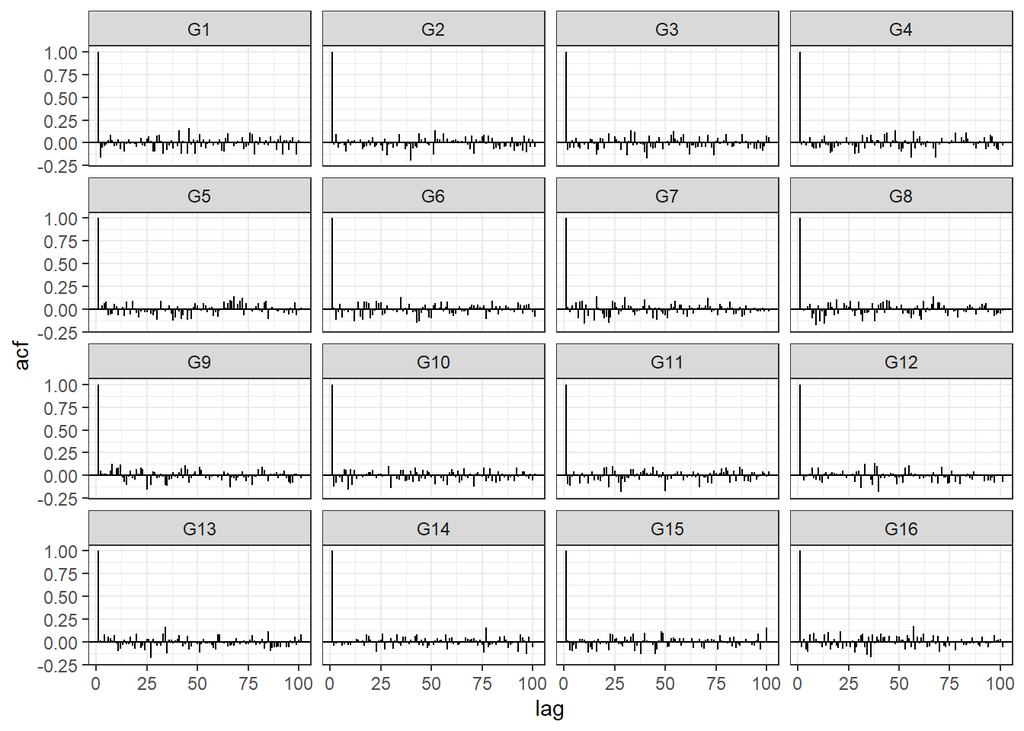

```r
acf_plot(
  stan_output = output,
  pars = "b",
  labels = paste0("G", seq_len(16))
)
```

Also, we could look directly at `b`’s Rhat values and effective sample sizes by running the `convergence_stats` function.

```r
convergence_stats(
  stan_output = output,
  pars = "b",
  labels = paste0("G", seq_len(16))
)
```

```
##    items    ess_b      rhat
## 1     G1 297.5469 0.9981490
## 2     G2 129.4015 1.0108605
## 3     G3 263.6723 0.9949979
## 4     G4 244.5576 0.9957586
## 5     G5 203.8961 1.0084407
## 6     G6 140.2473 0.9958602
## 7     G7 216.1331 1.0031004
## 8     G8 198.5456 0.9982122
## 9     G9 223.8507 1.0019909
## 10   G10 203.3586 0.9981526
## 11   G11 242.8318 0.9950432
## 12   G12 209.5226 1.0032004
## 13   G13 165.8209 0.9969650
## 14   G14 197.3338 0.9969247
## 15   G15 191.0946 1.0102361
## 16   G16 202.7867 1.0106220
```

## Parameter summary

### `b`

To summarize the `b` draws, `mxd` provides the `alphas()` function.

```r
alpha_scores <- alphas(
  stan_output = output,
  bw_size = 4,
  labels = paste0("G", seq_len(16)),
  anchor = TRUE
)
```

The output of `alphas()` is similar to the one of `mxd_logit_bayesian()` and has 4 objects:

- `alphas_raw`: the raw b utilities for all posterior draws (again the default for `thin`, thinning parameter, of `mxd_hb()` is set to `5`
- `alphas_zc`: the zero-centered utilities for all posterior `b` draws
- `beta_prob`: the choice probabilities for all posterior `b` draws
- `summary`: summary statistics of the 3 objects

### `sigma`

To summarize the `sigma` draws, `mxd` provides the `sigma_summary()` function.

```r
sigma_summary(
  stan_output = output,
  labels = paste0("G", seq_len(16))
)
```

```
##           mw        sd     2.5%    97.5%
## G1  4.903199 0.6083158 3.786651 6.172703
## G2  2.923598 0.4086434 2.204344 3.867669
## G3  3.276008 0.4264547 2.624924 4.245323
## G4  4.210636 0.5346163 3.326592 5.352760
## G5  4.290683 0.5244823 3.499562 5.384759
## G6  3.644131 0.4871888 2.810826 4.667739
## G7  3.795990 0.4863286 2.914975 4.761184
## G8  3.492115 0.4894647 2.710024 4.710127
## G9  5.876094 0.6858996 4.563134 7.274583
## G10 4.041724 0.5900837 3.029885 5.301022
## G11 3.872538 0.4617872 3.081757 4.895854
## G12 3.042707 0.4115439 2.280608 3.933730
## G13 2.734242 0.4009935 2.051293 3.544961
## G14 3.599794 0.4896293 2.801981 4.676385
## G15 3.806785 0.5449137 2.828099 4.974553
## G16 4.496459 0.5486308 3.448130 5.562292
```

### `beta`

`mxd` provides multiple functions for the `beta` scores (i.e., individual utilities). In the initial step, the user should prepare the draws accordingly, which is possible using the `betas_post()` function. Here the user has to specify the size of the MaxDiff tasks `bw_size` and whether it was an anchored MaxDiff (set `anchor` to `TRUE`) or unanchored MaxDiff (set `anchor` to `FALSE`). In addition, one can specify the *original ID’s* which were stored in the Stan input created by the `dm_to_stan_hb()` function, the labels that should be used as column names. Finally, in `betas_post()`, we allow to use multiple cores (`cores` argument) to speed up computation.

```r
betas_prep <- betas_post(
  stan_output = output,
  bw_size = 4,
  cores = 4L,
  ids = stan_input[["ids"]][["orig_id"]],
  labels = paste0("g", seq_len(16)),
  anchor = TRUE
)
```

Once prepared, we can get the summary statistic of the results. Since `betas_prep()` provides three different types of `beta` preparations, namely, the raw, the zero-anchored, and the choice probabilities scores, we can choose which we want to summarize. In the example below, we will use the raw utilities.

```r
betas_summary(
  betas = betas_prep[["beta_raw"]],
  vars = c(g1:ref)
)
```

```
##                mw        sd        2.5%      97.5%
## g1  -1.2082069865 0.2814802 -1.79503996 -0.7216285
## g2  -0.6735003733 0.2343781 -1.07126401 -0.1843532
## g3  -0.6681990236 0.2306202 -1.14186634 -0.2342570
## g4  -0.9187891766 0.2777728 -1.44611436 -0.3904494
## g5   0.9500904232 0.2880414  0.35239629  1.3950567
## g6   1.0245531988 0.2591709  0.56419431  1.5437053
## g7  -1.4471085674 0.2641264 -1.93543316 -0.8858338
## g8  -1.8756509039 0.2584450 -2.35714570 -1.4197612
## g9  -2.9310387077 0.3736358 -3.67687181 -2.3131391
## g10  0.4597656201 0.2611604 -0.01049963  0.9976290
## g11  0.6735226791 0.2630394  0.16804839  1.1942308
## g12 -0.1175713137 0.2098100 -0.53074191  0.2352608
## g13 -0.0001464763 0.2253987 -0.44595550  0.4495378
## g14 -2.9486343182 0.2828232 -3.54861977 -2.4120181
## g15  0.6112182746 0.2663607  0.10024048  1.1454433
## g16 -3.7239352591 0.3209082 -4.36000516 -3.0058087
## ref  0.0000000000 0.0000000  0.00000000  0.0000000
```

Alternatively, we could also show the choice probabilities.

```r
betas_summary(
  betas = betas_prep[["beta_prob"]],
  vars = c(g1:ref)
)
```

```
##            mw        sd      2.5%     97.5%
## g1  136.35322  8.575990 119.96147 152.87130
## g2  117.39441 10.734361  97.79272 138.21129
## g3  122.43746  9.074416 105.93288 139.30879
## g4  131.26873  8.559732 113.91266 149.27047
## g5  202.26624  9.192485 182.00704 218.25690
## g6  196.79520 10.485294 178.17329 217.31072
## g7  109.14878  7.840398  95.10356 125.41447
## g8   94.10890  7.069970  80.03402 107.26488
## g9   98.75437  6.831856  86.79923 113.39590
## g10 179.06834  9.188433 161.11673 195.54180
## g11 193.04508  9.286063 175.72037 211.95112
## g12 150.71018 10.165231 130.96007 170.12453
## g13 146.11049 11.647410 123.03882 169.17269
## g14  58.50461  7.653696  44.65723  74.73884
## g15 173.14063  9.694164 154.38326 192.24825
## g16  73.69522  7.624602  59.42037  87.89936
## ref 100.00000  0.000000 100.00000 100.00000
```

Often researchers use the aggregated utilities across all posterior draws. To get these, users can use the `bpe()` (i.e., beta point estimates) function. Here, the `id` argument is also required.

```r
bpe(
  betas = betas_prep[["beta_raw"]],
  vars = c(g1:ref),
  id = id
) |>
  head()
```

```
##   id        g1         g2          g3         g4        g5        g6        g7
## 1  1 -3.565914 -7.4713348 -0.09048486  6.7154716 -8.542405 -2.221909  5.393041
## 2  2 -5.409959  0.4917848  3.55204002  3.5890517 -2.379662  7.386817  6.103051
## 3  3  1.195448 -3.0632773 -1.00521471 -3.4435343 -7.092172 -1.348650  3.476654
## 4  4  1.212001 -3.7531688 -2.82606144  0.9307437 -1.249291 -6.836511 -6.697607
## 5  5 -5.581486 -1.8163385 -1.81401238  5.8491159 -9.553438  1.437185  3.073435
## 6  6 -8.604400 -2.2301043  0.37715911  7.8260455 -1.677760 -3.182979  5.513796
##          g8         g9       g10       g11         g12        g13       g14
## 1  3.926811  -2.904430 -7.642092 -6.534610  2.17957804 -1.9244004 -4.658772
## 2  1.380381 -11.424937  4.215517 -1.681210  2.69018544  1.6526846 -6.983867
## 3  3.736227  -2.444942  1.177087 -4.409913 -0.04066184 -3.2229746 -5.924912
## 4 -4.410903   4.907395 -6.149959 -5.518019 -0.65134499 -3.0346228 -1.576009
## 5  5.842363   2.732889 -3.588561 -8.075787 -3.74656078 -0.6259797 -5.302108
## 6  3.410595  -2.648697 -5.251092 -1.908461  2.47903864  1.7527247 -4.524805
##          g15        g16 ref
## 1 -2.1874101 -1.0612415   0
## 2 -1.6550966 -5.7066929   0
## 3 -0.5032243 -0.7109851   0
## 4 -1.4442453 -5.8276377   0
## 5 -2.5455820  4.7989813   0
## 6  2.6136651 -6.8736599   0
```

To plot the beta scores, `mxd` provides the `beta_violin()` function, which, similar to the `acf_plot()`, provides a `ggplot2` object as output and thus can we further adjusted by the user. For example below, we adjust the colors of the items. Below we plot the beta raw utilities and change the coloring of the violins.

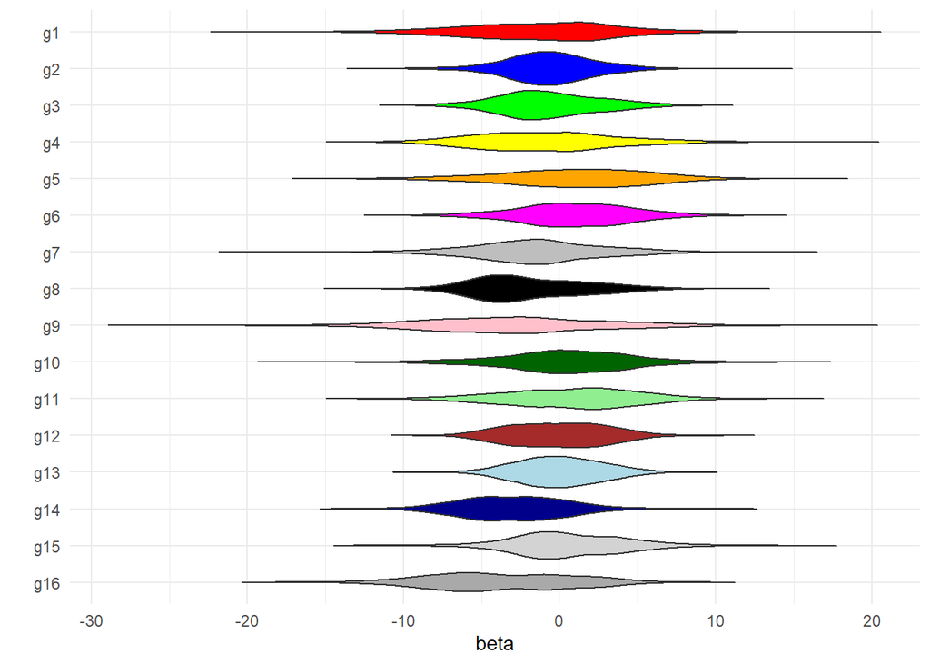

```r
betas_violin(
  betas = betas_prep[["beta_raw"]],
  vars = c(g1:g16),
  labels = paste0("g", seq_len(16))
) +
  ggplot2::scale_fill_manual(values = rev(c("red","blue", "green", "yellow",
                                   "orange", "magenta", "grey", "black",
                                   "pink", "darkgreen", "lightgreen", "brown",
                                   "lightblue", "darkblue", "lightgrey", "darkgrey")))
```

## Validation

Similar to the `validateHOT` package by (Schramm and Lichters 2025), `mxd` also provides tools for validation. However, the main difference is that `validateHOT` is intended to work with the beta point estimates, while `mxd` works with the posterior draws and in addition, some of its functions can also be applied to a validation sample. Furthermore, `mxd` also includes cross-valdiation tools. Let us explore them step-by-step.

### Internal fit

First, we load an additional data frame, in which we stored the actual choice in the holdout task.

```r
hot_data <- read.csv("../data/data.csv")
```

For internal fit, `mxd` provides both the `post_hit()` function to calculate the hit rate across the posterior draws and `post_mhp()` to calculate the mean hit probability across posterior draws. The user has to define the betas (`betas_post`), the data frame with the actual choices (`hot_data`), the participants identifier (`id`; has to be the same column name in both `betas_post` and `hot_data`), the alternatives in the validation task (`opts`), and the column name of the actual choice in the validation task (`hot_choice`). The output can be either summarized (`raw` set to `FALSE`) or for each iteration (`raw` set to `TRUE`).

```r
post_hit(
  betas_post = betas_prep[["beta_raw"]],
  hot_data = hot_data,
  id = id,
  opts = c(g1, g8, g9, g13, g14, g15, g16, ref),
  hot_choice = HOT1,
  raw = FALSE,
  group = NULL
)
```

```
## # A tibble: 1 × 4
##      mw    sd `2.5%` `97.5%`
##   <dbl> <dbl>  <dbl>   <dbl>
## 1  67.5  5.03     58    78.1
```

The setup for the `post_mhp()` function is the same.

```r
post_mhp(
  betas_post = betas_prep[["beta_raw"]],
  hot_data = hot_data,
  id = id,
  opts = c(g1, g8, g9, g13, g14, g15, g16, ref),
  hot_choice = HOT1,
  raw = FALSE
)
```

```
##          mw      sd     2.5%    97.5%
## mhp 60.1943 3.35521 54.31915 67.06884
```

### External fit

The functions `post_mae()`, `post_medae()`, and `post_rmse()` can be used for both internal as well as external fit. `post_mae()` calculates the mean absolute error,

```r
post_mae(
  betas_post = betas_prep[["beta_raw"]],
  hot_data = hot_data,
  opts = c(g1, g8, g9, g13, g14, g15, g16, ref),
  hot_choice = HOT1,
  raw = FALSE
)
```

```
##           mw        sd     2.5%    97.5%
## mae 1.963204 0.4908408 1.074376 2.984649
```

`post_medae()` calculates the median absolute error,

```r
post_medae(
  betas_post = betas_prep[["beta_raw"]],
  hot_data = hot_data,
  opts = c(g1, g8, g9, g13, g14, g15, g16, ref),
  hot_choice = HOT1,
  raw = FALSE
)
```

```
##             mw        sd      2.5%    97.5%
## medae 1.607781 0.5589261 0.6847209 2.889253
```

and finally, `post_rmse()` calculates the root mean square error.

```r
post_rmse(
  betas_post = betas_prep[["beta_raw"]],
  hot_data = hot_data,
  opts = c(g1, g8, g9, g13, g14, g15, g16, ref),
  hot_choice = HOT1,
  raw = FALSE
)
```

```
##            mw        sd     2.5%    97.5%
## rmse 2.460441 0.6190629 1.356245 3.686209
```

If the user wants to validate a validation sample instead, this data frame that should be predicted should be specified in `hot_data`.

## Cross-validation

However, often including a validation sample is not feasible for researchers. In addition, using holdout tasks is not always the recommended way of ensuring predictive validity. If no validation sample can be included, it is recommended to run a cross-validation, which we implemented in `mxd`. To prepare the input for estimation, we implemented the `dm_to_stan_hb_cv()` function, which is similar to the `dm_to_stan_hb()` function, however, one also has to define the number of folds (`folds`) as well as a seed (`seed`) for reproducing group assignment.

```r
cv_df <- dm_to_stan_hb_cv(
  design = dm,
  id = ID,
  cs = Set,
  alt = alt,
  items = c(Item_1:Item_17),
  ch = choice,
  folds = 5L,
  seed = 1910,
  demos = NULL
)
```

Next, we can run the `mxd_hb_cv()` function. This function requires the created input using the `dm_to_stan_hb_cv()`. The arguments that are required are the same as for `mxd_hb()`.

```r
mxd_cv <- mxd_hb_cv(
  data_stan = cv_df,
  iter = 800,
  warmup = 400,
  seed = 1910
)
```

```
## Fold 1 estimating ...
```

```
## Fold 2 estimating ...
```

```
## Fold 3 estimating ...
```

```
## Fold 4 estimating ...
```

```
## Fold 5 estimating ...
```

Finally, we can run the validation for each fold. `mxd` provides three functions to assess validity, `post_mae_cv()` (for mean absolute error), `post_medae_cv()` (for median absolute error), and `post_rmse_cv()` for root mean square error. The user has to define the output from the cross-validation estimation (`stan_cv`), the input that was provided to the `mxd_hb_cv()` function (`stan_input`), the data frame with the actual choices in the holdout task (`hot_data`), the alternatives in the validation task (`opts`), the column name of the participants’ identifier in the estimation model `val_id`, the column name of the participants’ identifier in `hot_data` (`hot_id`), and the actual choice in the validation question (`hot_choice`). Again, the output can be the summary (set `raw` to `FALSE`) or the validation results of each iteration (set `raw` to `TRUE`).

```r
post_mae_cv(
  stan_cv = mxd_cv,
  stan_input = cv_df,
  hot_data = hot_data,
  val_id = ID,
  hot_id = id,
  opts = c(g1, g8, g9, g13, g14, g15, g16, ref),
  hot_choice = HOT1,
  labels = c(paste0("g", c(1:16)), "ref"),
  raw = FALSE
)
```

```
## # A tibble: 6 × 5
##   sample    mw    sd `2.5%` `97.5%`
##   <chr>  <dbl> <dbl>  <dbl>   <dbl>
## 1 1       9.46 0.717   7.91   10.8
## 2 2       7.11 0.746   5.79    8.53
## 3 3       8.48 0.670   7.20    9.74
## 4 4      10.2  0.911   8.58   11.9
## 5 5       8.65 0.853   6.96   10.2
## 6 mean    8.77 0.779   7.29   10.2
```

Alternatively, we could also evaluate predictive validity relying on the median absolute error instead.

```r
post_medae_cv(
  stan_cv = mxd_cv,
  stan_input = cv_df,
  hot_data = hot_data,
  val_id = ID,
  hot_id = id,
  opts = c(g1, g8, g9, g13, g14, g15, g16, ref),
  hot_choice = HOT1,
  labels = c(paste0("g", c(1:16)), "ref"),
  raw = FALSE
)
```

```
## # A tibble: 6 × 5
##   sample    mw    sd `2.5%` `97.5%`
##   <chr>  <dbl> <dbl>  <dbl>   <dbl>
## 1 1       8.69 1.13    6.48   10.8
## 2 2       5.60 0.844   4.05    7.27
## 3 3       5.70 0.907   4.02    7.66
## 4 4       6.76 0.770   5.47    8.61
## 5 5       7.58 1.16    5.50   10.0
## 6 mean    6.87 0.961   5.10    8.87
```

For demonstration purposes, we also show the code for the root mean square error

```r
post_rmse_cv(
  stan_cv = mxd_cv,
  stan_input = cv_df,
  hot_data = hot_data,
  val_id = ID,
  hot_id = id,
  opts = c(g1, g8, g9, g13, g14, g15, g16, ref),
  hot_choice = HOT1,
  labels = c(paste0("g", c(1:16)), "ref"),
  raw = FALSE
)
```

```
## # A tibble: 6 × 5
##   sample    mw    sd `2.5%` `97.5%`
##   <chr>  <dbl> <dbl>  <dbl>   <dbl>
## 1 1      10.8  0.777   9.21    12.3
## 2 2       8.74 0.915   7.06    10.6
## 3 3      10.8  0.818   9.17    12.3
## 4 4      12.8  1.02   11.1     14.9
## 5 5      10.2  1.02    8.28    12.1
## 6 mean   10.7  0.909   8.96    12.4
```

# References

Aizaki, Hideo, and James Fogarty. 2023. “R Packages and Tutorial for Case 1 Best-Worst Scaling” 46: 100394. https://doi.org/10.1016/j.jocm.2022.100394.

Gabry, Jonah, and Duco Veen. 2022. “Shinystan: Interactive Visual and Numerical Diagnostics and Posterior Analysis for Bayesian Models.” https://CRAN.R-project.org/package=shinystan.

Helveston, John Paul. 2023. “Logitr: Fast Estimation of Multinomial and Mixed Logit Models with Preference Space and Willingness-to-Pay Space Utility Parameterizations” 105. https://doi.org/10.18637/jss.v105.i10.

Sailer, Martin Oliver. 2022. “Crossdes: Construction of Crossover Designs.” https://CRAN.R-project.org/package=crossdes.

Schramm, Joshua Benjamin, and Marcel Lichters. 2025. “validateHOT - an r Package for the Analysis of Holdout/Validation Tasks and Other Choice Modeling Tools.” *Journal of Open Source Software* 10 (107): 6708. https://doi.org/10.21105/joss.06708.

Stan Development Team. 2025. “RStan: The r Interface to Stan.” https://mc-stan.org/.

Wickham, Hadley, Mara Averick, Jennifer Bryan, Winston Chang, Lucy D’Agostino McGowan, Romain François, Garrett Grolemund, et al. 2019. “Welcome to the Tidyverse” 4: 1686. https://doi.org/10.21105/joss.01686.